# Tidy Tuesday 06/08/2019

# Data description

Each of the columns after episode/title correspond to the binary presence (0 or 1) of that element in the painting.

# Import data and packages

```r
#bob_ross <- readr::read_csv("https://raw.githubusercontent.com/rfordatascience/tidytuesday/master/data/2019/2019-08-06/bob-ross.csv")
#write_csv(bob_ross, "boss_ross.csv")
bob_ross <- readr::read_csv("boss_ross.csv")


library(tidyverse)
library(visNetwork)
library(igraph)
library(tidygraph)
library(ggraph)
library(Cairo)
```

# Data

```r
#recommended step to clean episode information and frame elements
#I'll only work with the paintings

bob_ross <- bob_ross %>%
  janitor::clean_names() %>%
  separate(episode, into = c("season", "episode"), sep = "E") %>%
  mutate(season = str_extract(season, "[:digit:]+")) %>%
  mutate_at(vars(season, episode), as.integer) %>%
  select(-c(contains("frame"), title))

dim(bob_ross)
```

```
## [1] 403  53
```

Very wide dataframe. Let’s change it to a long, tidy format.

```r
bob_ross <- bob_ross %>%
  gather("element", "presence", -c(season, episode))
```

This get us a lot of lines with zeroes, let’s dispose of them.

```r
bob_ross <- bob_ross %>%
  filter(presence >0)
```

# EDA

Now a little exploratory analysis.

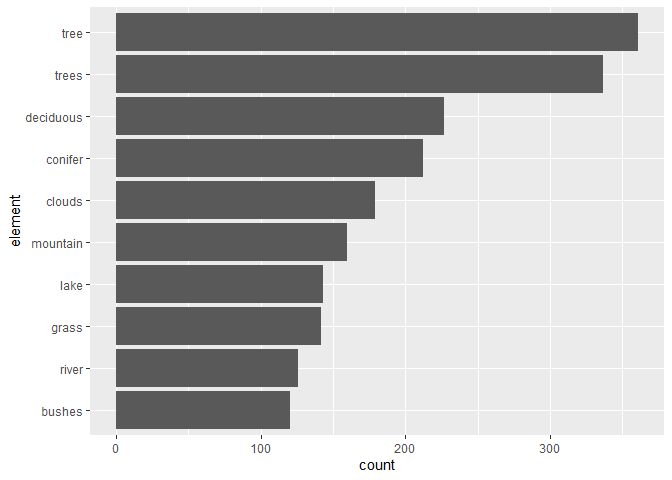

```r
bob_ross %>%
  count(element) %>%
  top_n(10, n) %>%
  ggplot(aes(x = reorder(factor(element), n),
             y = n)) +
    geom_col() +
    labs(x = "element", y ="count") +
  coord_flip()
```

So tree, and trees, are the most common elements. The top 10 elements in general are related with nature, landscapes and backgrounds.

Let’s take a closer look to tree and trees.

```r
bob_ross %>%
  group_by(season, episode) %>%
  summarise(
    only_tree = ifelse(any(element == "tree") & !(any(element == "trees")), 1, 0),
    only_trees = ifelse(!any(element == "tree") & (any(element == "trees")), 1, 0),
    both_tree_trees = ifelse(any(element == "tree") & (any(element == "trees")), 1, 0)
  ) %>%
  ungroup() %>%
  select(-c(season, episode)) %>%
  summarise_all(sum)
```

| only_tree | only_trees | both_tree_trees |
| --- | --- | --- |
| 24 | 0 | 337 |

So trees is not very informative, since it only says if more than one tree is in the picture and not a really new element. Let’s take away this element and refer to tree as “at least one tree”. And let’s do the same for mountains.

```r
bob_ross <- bob_ross %>%
  filter(element != "trees", element != "mountains")
```

# Network graph

## Preparing the nodes

First we create a data frame of nodes, with individual ids for each element name (label).

```r
nodes <- bob_ross %>%
  group_by(season, episode) %>%
  mutate(count_el = sum(presence)) %>%
  dplyr::filter(count_el > 1) %>%
  ungroup() %>%
  select(label = element) %>%
  distinct() %>%
  rowid_to_column("id")
```

So we have 48 unique nodes for our network graph, which is all elements with the exception of *lakes*, which isn’t present in any painting, *trees*, *mountains* and frame elements.

Now preparing the edges. Probably there’s a better way to do this but this large set of steps is what I could come up with. It involves:

- Creating a table with the element counts;
- Join it with itself to create the connections;
- Eliminate the elements’ connections to themselves created by the join.
- Eliminate the mirrored connections. Since join repeats rows that are only a partial match, all combinations are considered and we end up with every connection twice.
- Label the connections with the correct ids.

```r
#Creates a variable of element counts
edges_i <- bob_ross %>%
  group_by(season, episode) %>%
  mutate(count_el = sum(presence)) %>%
  dplyr::filter(count_el > 1) %>% #just to make sure there isn't any element without a connection
  ungroup() %>%
  select(-c(presence,count_el))

#Creates a table of top 100 connections and their sizes
edges_l <- edges_i %>%
  inner_join(edges_i, by = c("season", "episode")) %>%
  dplyr::filter(element.x != element.y) %>%
  group_by(grp = paste(pmax(element.x, element.y), pmin(element.x, element.y), sep = "_"), season, episode) %>%
  slice(1) %>%
  ungroup() %>%
  select(-c(grp, season, episode)) %>%
  group_by(element.x, element.y) %>%
  summarise(value = n()) %>%
  ungroup() %>%
  top_n(100, value)

#Label the connections correctly
edges <- edges_l %>%
  left_join(nodes, by = c("element.x" = "label")) %>%
  rename(from = id) %>%
  left_join(nodes, by = c("element.y" = "label")) %>%
  rename(to = id) %>%
  select(from, to, value)
```

Then we’ll look into the nodes again to only select the nodes that appear in the top 100 connections, so we don’t have any isolated node in the network.

```r
#Get only the nodes that are in the top 100 connections
nodes_chose <- nodes %>%
  dplyr::filter(id %in% c(edges$from, edges$to))

#Variable for size of the nodes
nodes_chose$size <- bob_ross %>%
  dplyr::filter(presence == 1) %>%
  count(element) %>%
  inner_join(nodes_chose, by = c("element" = "label")) %>%
  .$n/10
```

## Create the interactive network

With visNetwork package it’s easy to create a network element. But we have to try it some times to choose a good seed and solver algorithm and parameters. I didn’t discover how to make annotations, so I tried to give the minimum relevant information in title and subtitle. And fade them a little so they don’t take attention away from the data.

```r
#create visualization
#Html content. Not run in the md.
visNetwork(nodes_chose, edges,
           main = list( text = "What elements does Bob Ross paint together?",
                        style = 'font-family:Georgia, Times New Roman, Times, serif;
                        font-weight:bold;font-size:20px;text-align:left;color:slategray;'
                        ),
           submain = list(text = 'Close circles have similar pairings, large circles are common elements, thick lines are common pairings' ,
                          style ='font-family:Georgia, Times New Roman, Times, serif;
                          font-size:13px;text-align:left;color:slategray'
                          )
           )%>%
  visNodes(color = list(background = "steelblue",
                        border = "lightblue",
                        highlight = "orange"),
           font = list(size = 16)
           ) %>%
  visEdges(color = list(color = "lightblue", highlight = "steelblue")
           ) %>%
  visPhysics(solver = "forceAtlas2Based",
             forceAtlas2Based = list(gravitationalConstant = -22)
             )%>%
  visLayout(randomSeed = 100) %>%
  visInteraction(navigationButtons = TRUE)
```

[interactive chart not shown]

## Creating a still network

I also created a still network using ggraph package, but the image didn’t render nicely using windows.

```r
edges <- edges %>%
  top_n(10, value)


nodes_chose <- nodes %>%
  dplyr::filter(id %in% c(edges$from, edges$to))

nodes_chose$size <- bob_ross %>%
  count(element) %>%
  inner_join(nodes_chose, by = c("element" = "label")) %>%
  .$n/10

br_igraph <- graph_from_data_frame(d = edges[,1:3], vertices = nodes_chose[,1:2], directed = TRUE)

br_tidy <- as_tbl_graph(br_igraph)

windowsFonts("Arial Narrow" = windowsFont("Arial"))

p <- ggraph(br_tidy, layout = "linear") +
  geom_edge_arc(aes(width = value), alpha = 0.8) +
  scale_edge_width(range = c(0.2, 3)) +
  geom_node_text(aes(label = label), size = 5) +
  labs(title = "Bob Ross' top 10 pairings in paintings",
       subtitle = "He sure loves vegetation",
    edge_width = "Nº of ocurrences") +
  theme_void()
```

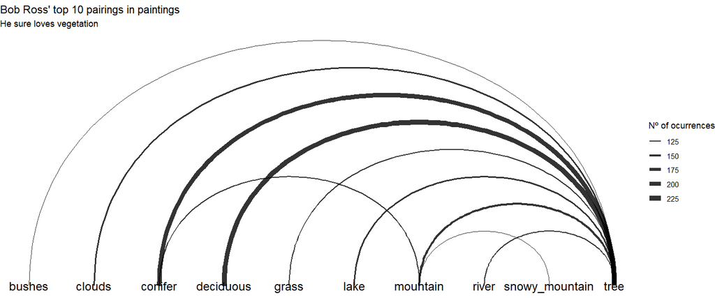

```r
p
```